# Variation in distance between consecutive animal locations

Abstract

# Introduction

Movement is a fundamental ecological process, critical to an animal’s biology and it’s interactions with the environment. The study of animal movement tends to focus on four basic mechanistic questions: the why, when, where, and how an animal moves, and these questions can be answered at the scale of individuals or populations. A general framework for movement ecology is needed to link movement patterns and processes. Such a framework would start with a focus on movement itself and the individual’s internal state, navigation capacity, motion capacity, and responses to external factors (Nathan *et al.* 2008). The overall goal of studying movement is to find the linkages between the causes and mechanisms of animal movement, that explain spatiotemporal patterns that then feed back into various ecological and evolutionary processes. However, we can also focus on the effects and consequences that different movement patterns can have over species interactions and other ecological processes.

Random walks have been used broadly in biology to model movement of animals and microorganisms, starting with the simplest models of movement using uncorrelated and unbiased random walks (Codling *et al.* 2008). These movement models show no preference in direction and movement at each step is completely independent of the direction taken in previous movements. Extensions of simple random walk processes are regularly used to accommodate for more complex behaviors or to include drift. Some of these extensions involve the use of correlated random walks, which incorporate a correlation between directions in successive movements, biased random walks, which incorporate a directional bias, or even building movement models as mixtures of random walks to account for more complex behaviors (Morales *et al.* 2004). Modeling approaches using random walks generally assume a homogeneous environment and behaviors that don’t drastically change the movement pattern (Kareiva & Shigesada 1983). A simple random walk approximates displacements by connecting a series of straight lines, and can summarize animal movement based on parameters for movement length and turning angle, or the use of net squared displacement. Connecting theoretical movement models based on correlated random walks to data had often relied on the use of these parameters or displacement measures (Turchin 1998), but more current and efficient approaches have used likelihood-based techniques to estimate parameters by fitting a discrete approximation of the model directly to the location data (Jonsen *et al.* 2003).

In the context of species interactions and the consequences of animal movement to dispersal, the general focus has been on understanding how the typical movement patterns, built around average measures at population levels, can influence plant population spread (Levey *et al.* 2005), seed dispersal Holbrook *et al.* (2007), pollen dispersal (Garcia *et al.* 2007), and even pathogens (Shaw *et al.* 2017). Animal movement can be modeled with a simple diffusion process or a random walk (Levey *et al.* 2005; Jones *et al.* 2017), with the simplest approach assuming model parameters are the same across individuals, something known as ‘complete pooling’ (Langrock *et al.* 2012). This focus on generality has driven to a lack of frameworks for understanding how variation in animal movement is maintained, and the consequences of this variation across populations and communities. From the animal movement perspective, some alternatives have been considered to incorporate individual variation with ‘no pooling’ or ‘partial pooling’ approaches, where each or some individuals have their own set of parameters Jonsen *et al.* (2006), however a high number of parameters quickly limits applications to high levels of individual variation. The decision to pool data or not may also come from the modeling framework chosen, as frameworks that allow for random effects may have a better structure to incorporate this variation than simpler frameworks. Recent calls for incorporating individual variation in movement and their consequences to seed dispersal or even pathogen spread Shaw (2020) have pushed for the need to develop theory that explores different types of variation in movement patterns to understand its consequences across ecological organizational levels. In particular, when considering species interactions, incorporating individual variation becomes essential to understand how positive or negative feedback loops play into the maintenance of variation in movement as individuals respond to external factors in their environment.

Animal telemetry data are collected by determining an animal’s location at various points in time. Many of the movement models used to analyze animal telemetry data rely on regular time intervals between locations (Jonsen *et al.* 2003, 2005). However, based on field methods, or environmental variables such as heavy cloud cover or dense forest, can make data collection at regular intervals difficult, and thus location data becomes more opportunistic and with irregular time intervals. Previous methods to analyze data under these irregular conditions have relied on interpolating, subsampling, or aggregating data during pre-processing in order to make it fit model assumptions(Johnson *et al.* 2008). In this study, we propose the use of a model capable of handling irregular time intervals by considering movement as a stochastic process on a continuous time scale, and thus focus on the animal’s instantaneous velocity rather than on its absolute displacements between locations. Using this continuous-time framework, we are able to estimate movement paths by integrating velocity functions. We also explore the effects of individual variation in speeds as a comparison between velocity probability density functions across different levels of data aggregation between individuals. Unlike other studies which focus on deciphering the underlying behaviors from animal movement data, our focus was to uncover potential differences between individuals and how these differences can be obscured when modeling population-level animal movement. We know these simple correlated random walks, or simple movement models might not be enough to describe net displacements under more complex processes, for which developments in state-space modeling frameworks show to be promising. However, our goal in this study was to use a simpler model that would adjust to irregular and sparse telemetry data, and focus on potential differences that arise when comparing data from multiple individuals under frameworks that completely pool data in contrast to those that don’t. We illustrate the use of this model and the individual variation comparison by analyzing a telemetry data set of twelve many-banded aracari individuals, *Pteroglossus pluricinctus*.

**2021-05-03**

- Explain what levy processes are and why they are suggested. Random search for resources.
- Classical random walks for homogeneous environments, and in more complex environments, use mixtures of these ‘classical’ random walks, to show the animals adaptability to the changes in the environment.
- Levy walks claimed to be more efficient than classical random walks for search or activity patterns.
- Levy walks are non-oriented and superdiffusive. Interesting too because they may be involved when the random variable follows a power-law distribution.
- Classical random walks have step lengths distributed with finite variance, and in their simplest form, both their step length and turning angles are uniformly distributed. Levy walks are also uncorrelated and unbiased, like mere random walks, but their step lengths are characterized by infinite variance (i.e. drawn from a heavy-tail distribution). simplest example with a pareto distribution. [Benhamou 2007]

Bartumeus 2007 Levy-type processes can be relevant in large-scale animal movement.

# Methods

## Velocity-based continuous-time model

We developed an animal movement model with telemetry data in mind, thus we considered a movement trajectory as a series of consecutive recordings of an animal’s location. To first set up the framework for a velocity-based model, we consider movement as the change in locations across two coordinates. We let $\boldsymbol{u}(t)=[u_x(t), u_y(t)]'$ be the location of an individual at time $t$ in the coordinates $x$ and $y$. We establish $\boldsymbol{d}_{\Delta}(t) = \boldsymbol{u}(t+\Delta) - \boldsymbol{u}(t)$ as the difference in locations across both coordinates over $\Delta$ time units. The differential equation $d\boldsymbol{u}(t)=\boldsymbol{v}(t)dt$ represents the instantaneous velocity as $\Delta$ approaches zero under the assumption that $\boldsymbol{u}(t)$ is a continuous movement path (Johnson *et al.* 2008). Although the bivariate velocity process $\boldsymbol{v}(t) = [u_x(t), u_y(t)]'$ could be considered as cross-correlated between the axes, these correlated velocities produce strange directed travel and thus velocity in each coordinate is considered to be an independent process (Johnson *et al.* 2008). We decided instead, to focus on a velocity-based movement process using velocity scalars and turning angles. Under this framework, we define a scalar for instantaneous directionless velocity as
$$v(t+\Delta) = \sqrt{(u_x(t+\Delta)-u_x(t))^2 + (u_y(t+\Delta) - u_y(t))^2}$$
and assume $v(t)$ to be a random variable with probability density $h(\boldsymbol\sigma)$ where $\boldsymbol\sigma$ represents the vector of parameters and determines the overall variability in velocity. We assumed velocities to be independent of turning angles and chose to describe each with a separate probability density function, which is common practice when using movement lengths (Kareiva & Shigesada 1983). We calculated the turning angle $\theta(t+\Delta)$ describing the turning direction of the animal at time $t+\Delta$ and assumed the distribution of angles along a continuous movement path to be distributed with probability density $g(\theta)$. For the specific case of a correlated random walk, the distribution of $g(\theta)$ can be used as a measure of correlation in the direction of movement, where if no correlation is present, the distribution is uniform (Kareiva & Shigesada 1983). As in other papers, we adopt the convention of using upper case letters for random variables and lower case letters for possible numerical values of these random variables.

Using this velocity process and turning angles, the continuous-time location process $\boldsymbol{u}(t)$ can be obtained by integrating over the velocity process (Johnson *et al.* 2008):
$$\boldsymbol{u}(t) = \boldsymbol{u}(0) + \int_0^t\boldsymbol{v}(\tau)d\tau$$
where
$$\int_0^t\boldsymbol{v}(\tau)d\tau =\int_0^t [v_x(\tau), v_y(\tau)]' d\tau = \int_0^t [\sin(\theta_\tau), \cos(\theta_\tau)]' \cdot v(\tau)d\tau$$
This integral describes the location at time $t$ as the sum of steps determined by velocities in each direction plus a starting location at time $t=0$.

## Model evaluation using information criteria

$$AIC{_{indlevel}} = 2 \cdot \sum \left ( number parameters \right ) + 2 \cdot \sum \left ( negative log likelihood \right )$$

$$AICc{_{indlevel}} = AIC{_{indlevel}} + (2 \cdot \sum{nparams} \cdot \left(\sum{nparams}+1\right)/\left(\sum{observations} - \left(\sum{nparams} - 1\right)\right)$$

$$BIC_{indlevel} = \ln{\sum observations} \cdot \sum{number parameters} + 2\cdot \sum {negative log likelihood}$$

## Example: Many-banded aracari movement

We focused our study of individual variation on the many-banded araçari (*Pterglossus pluricinctus*), a small toucan in Yasuní National Park, Ecuador. We used previously collected data from studies using radiotelemetry to estimate home ranges and evaluate the potential seed dispersal distances for the *Virola flexuosa* tree (Holbrook 2011). Over a period of four years, from 2001 to 2005, *P. pluricinctus* individuals were captured and radio-transmitters were attached at the base of the central tail feathers (Holbrook 2011). Toucan locations were estimated by triangulation using receivers and hand-held antennas, with tracking periods lasting between 4-5 hours per day, locating individual birds every 15 minutes. Further details on field methods can be found in Holbrook (2011). It is important to note that these methods did not track all birds simultaneously, and that although individual toucan locations were attempted every 15 minutes, this was not always possible, thus some successive locations have time categories associated to multiples of 15. Due to the nature of the data, and the irregular time lags between two consecutive locations, previous work calculated movement rate for each individual in order to take advantage of all the data despite variable time intervals (see Table 1 in Holbrook 2011). Movement rates were calculated as the displacement in meters over the total length of the tracking period in minutes, where the tracking period was defined as the total active tracking time for a bird over the season when the data was collected. In other words, the movement rate could be defined as the average velocity of the animal over the entire tracking period, and thus there is one movement rate value associated to each individual bird. In our case, we wanted to extend the use of the telemetry data and use all locations in a modeling framework. From the relocation data, we calculated animal trajectories by considering discrete steps between successive relocations of each animal (Turchin 1998), quantifying their turning angle after each movement, estimating the Euclidean distance between successive relocations, and estimating the velocity for each segment as the displacement distance divided by the length of the time interval. We used the package ‘adehabitatLT’(Calenge 2006) in R (R Core Team 2020) to calculate other descriptive parameters for each trajectory, such as turning angles and net squared displacement.

# Results

## Fitting velocity probability density functions

We compared the fit of the different probability distributions to animal movement rate data with Akaike’s Information Criteria(AIC) and it’s corrected version for small sample sizes (AICc), we also used the Bayesian Information Criteria (BIC) to compare these model fittings. At the population level, all information criteria concur and show that the lognormal model fits the data for movement rates the best, with the weibull model next, see table 1. However, as we visually assessed fit of these models with QQ plots and goodness-of-fit statistics (see the supplemet), the lognormal distribution model greatly overestimates the data towards the tail, whereas all the other models are significantly more conservative and tend to underestimate the data.

At the individual level, we observed similar outcomes, where the lognormal distribution consistently overestimated the data, whereas the other distributions considered did not. When comparing across distribution models at the individual level, AIC and AICc showed the lognormal fit as the best one followed by the exponential model, whereas the BIC had the exponential as the best model followed by the lognormal.

When comparing the population level models with the ones at the individual level, we found that information criteria differed. In the case of AIC and AICc, these consistently categorized the individual level models as best fitting when compared to their equivalent distribution model at the population level. However, BIC values show that only when we consider the exponential distribution model does the individual level do a better fitting than the population, with all other models having higher BIC values for the models that include individual heterogeneity.

Figure 1. Probability densities of velocities for each individual bird (gray lines) compared to the complete pooling of data (light blue).

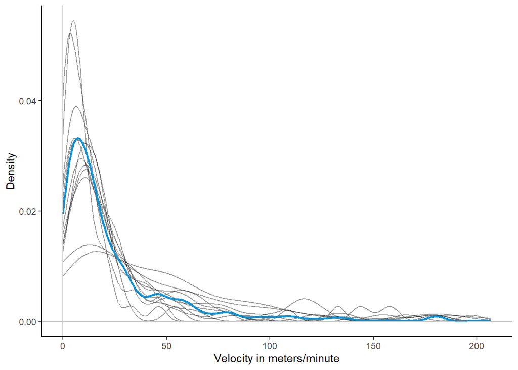

Figure 2. Probability densities of turning angles in radians

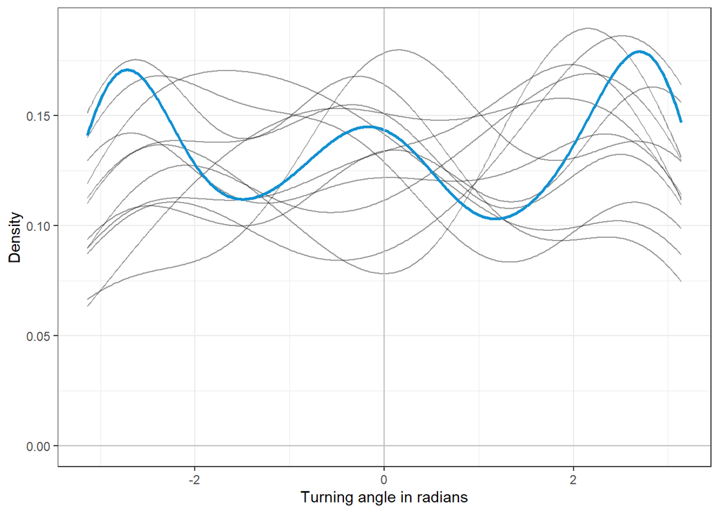

Figure 3. Comparison between histograms of turning angles in degrees for individuals versus complete pooling of data.

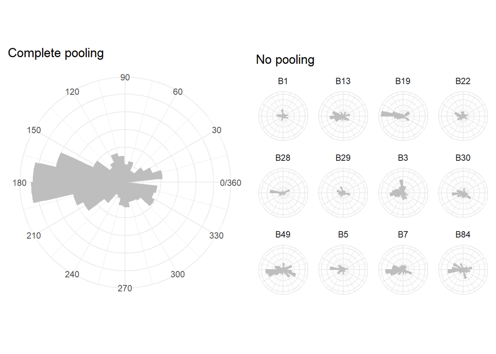

[output not shown]

[output not shown]

[output cut: 436 more lines]

[output not shown]

Figure 4. QQplot fits of each distribution model to the velocity data

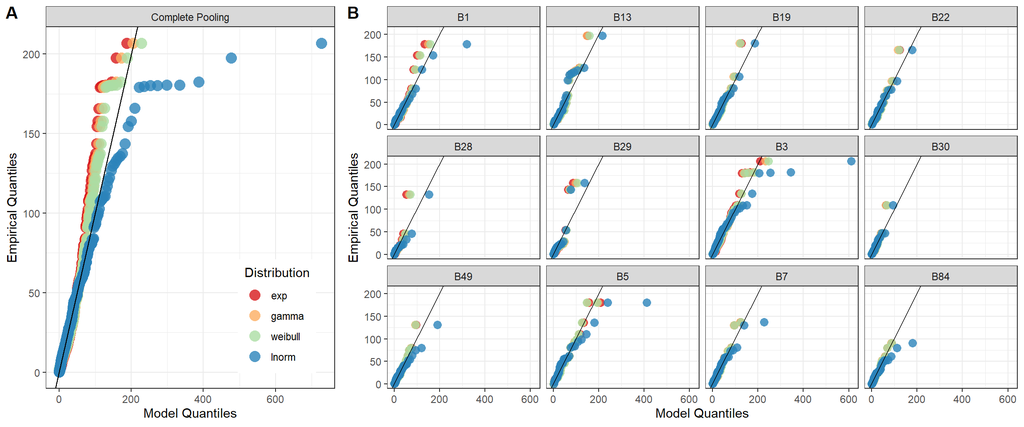

## Information criteria

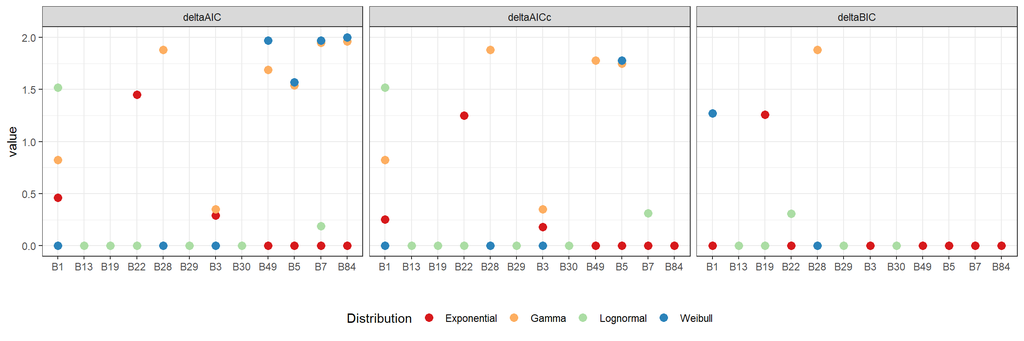

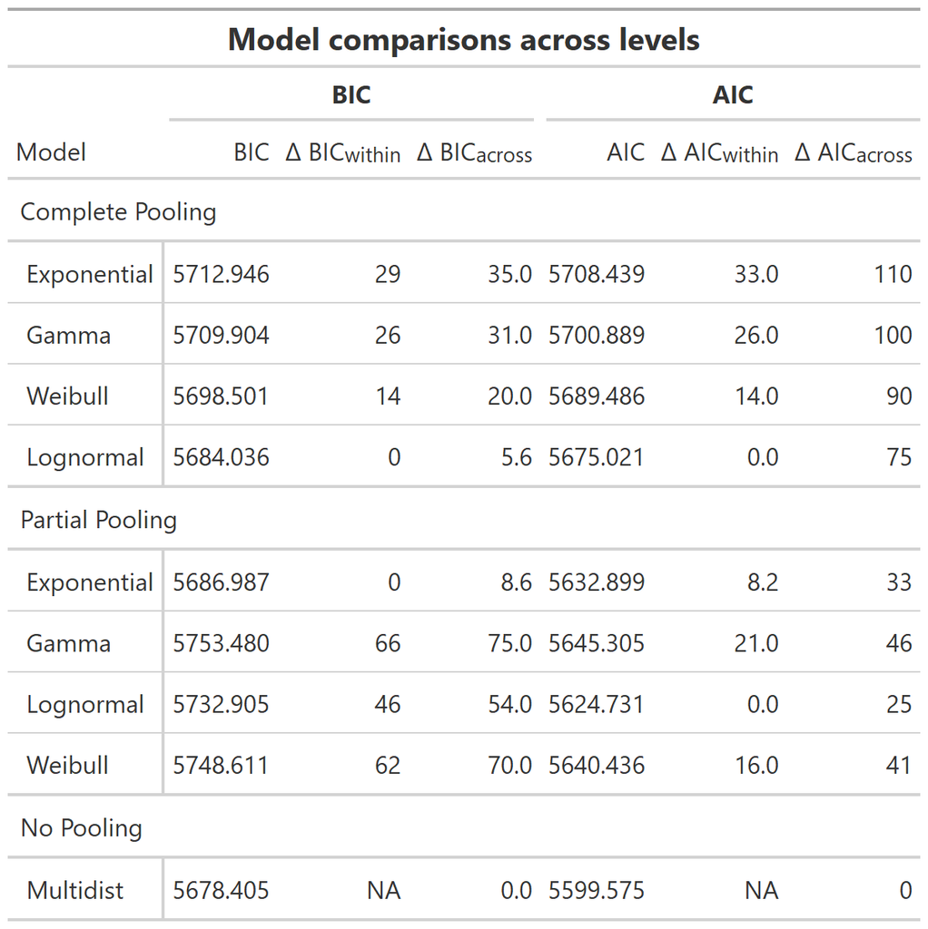

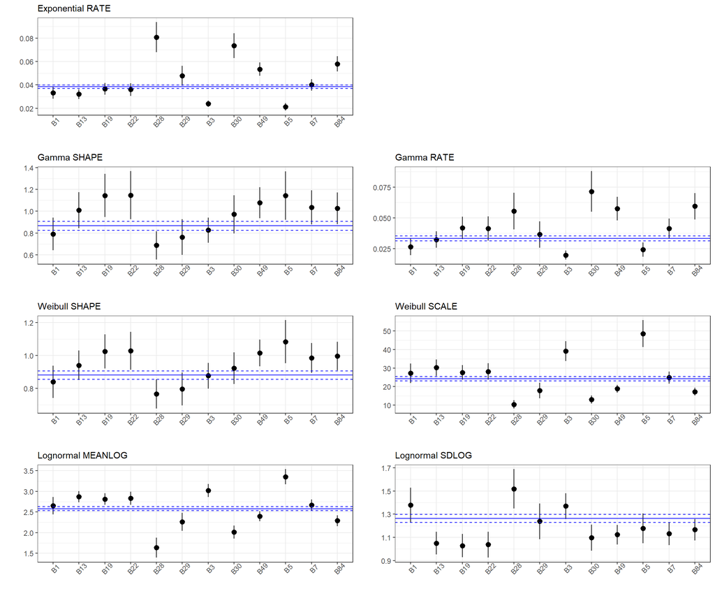

# References

Calenge, C. (2006). The package adehabitat for the r software: Tool for the analysis of space and habitat use by animals. *Ecological Modelling*, 197, 1035.

Codling, E.A., Plank, M.J. & Benhamou, S. (2008). Random walk models in biology. *Journal of the Royal society interface*, 5, 813–834.

Garcia, C., Jordano, P. & Godoy, J.A. (2007). Contemporary pollen and seed dispersal in a prunus mahaleb population: Patterns in distance and direction. *Molecular Ecology*, 16, 1947–1955.

Holbrook, K., Loiselle, B. & others. (2007). Using toucan-generated dispersal models to estimate seed dispersal in amazonian ecuador. *Seed dispersal: theory and its application in a changing world*, 300–321.

Holbrook, K.M. (2011). Home range and movement patterns of toucans: Implications for seed dispersal. *Biotropica*, 43, 357–364.

Johnson, D.S., London, J.M., Lea, M.-A. & Durban, J.W. (2008). Continuous-time correlated random walk model for animal telemetry data. *Ecology*, 89, 1208–1215.

Jones, L.R., Duke-Sylvester, S.M., Leberg, P.L. & Johnson, D.M. (2017). Closing the gaps for animal seed dispersal: Separating the effects of habitat loss on dispersal distances and seed aggregation. *Ecology and evolution*, 7, 5410–5425.

Jonsen, I.D., Flemming, J.M. & Myers, R.A. (2005). Robust state–space modeling of animal movement data. *Ecology*, 86, 2874–2880.

Jonsen, I.D., Myers, R.A. & Flemming, J.M. (2003). Meta-analysis of animal movement using state-space models. *Ecology*, 84, 3055–3063.

Jonsen, I.D., Myers, R.A. & James, M.C. (2006). Robust hierarchical state-space models reveal diel variation in travel rates of migrating leatherback turtles. *Journal of Animal Ecology*, 75, 1046–1057.

Kareiva, P. & Shigesada, N. (1983). Analyzing insect movement as a correlated random walk. *Oecologia*, 56, 234–238.

Langrock, R., King, R., Matthiopoulos, J., Thomas, L., Fortin, D. & Morales, J.M. (2012). Flexible and practical modeling of animal telemetry data: Hidden markov models and extensions. *Ecology*, 93, 2336–2342.

Levey, D.J., Bolker, B.M., Tewksbury, J.J., Sargent, S. & Haddad, N.M. (2005). Effects of landscape corridors on seed dispersal by birds. *Science*, 309, 146–148.

Morales, J.M., Haydon, D.T., Frair, J., Holsinger, K.E. & Fryxell, J.M. (2004). Extracting more out of relocation data: Building movement models as mixtures of random walks. *Ecology*, 85, 2436–2445.

Nathan, R., Getz, W.M., Revilla, E., Holyoak, M., Kadmon, R., Saltz, D., *et al.* (2008). A movement ecology paradigm for unifying organismal movement research. *Proceedings of the National Academy of Sciences*, 105, 19052–19059.

Patterson, T.A., Basson, M., Bravington, M.V. & Gunn, J.S. (2009). Classifying movement behaviour in relation to environmental conditions using hidden markov models. *Journal of Animal Ecology*, 78, 1113–1123.

R Core Team. (2020). *R: A language and environment for statistical computing*. R Foundation for Statistical Computing, Vienna, Austria.

Shaw, A.K. (2020). Causes and consequences of individual variation in animal movement. *Movement ecology*, 8, 1–12.

Shaw, A.K., Peace, A., Power, A.G. & Bosque-Pérez, N.A. (2017). Vector population growth and condition-dependent movement drive the spread of plant pathogens. *Ecology*, 98, 2145–2157.

Snell, R.S., Beckman, N.G., Fricke, E., Loiselle, B.A., Carvalho, C.S., Jones, L.R., *et al.* (2019). Consequences of intraspecific variation in seed dispersal for plant demography, communities, evolution and global change. *AoB Plants*, 11, plz016.

Turchin, P. (1998). *Quantitative analysis of movement: Measuring and modeling population redistribution in animals and plants*. Sinauer Associates.